# Major Project - Titanic Classification Models Part 2

# by Sanjana Rao

**Problem Statement :** The sinking of the RMS Titanic is one of the most infamous shipwrecks in history. On April 15, 1912, during her maiden voyage, the Titanic sank after colliding with an iceberg, killing numerous passengers and crew. This sensational tragedy shocked the international community and led to better safety regulations for ships.

One of the reasons that the shipwreck led to such loss of life was that there were not enough lifeboats for the passengers and crew. Although there was some element of luck involved in surviving the sinking, some groups of people were more likely to survive than others, such as women, children, and the upper-class.

In this, we ask you to complete the analysis of what sorts of people were likely to survive. In particular, we ask you to apply the tools of machine learning to predict which passengers survived the tragedy.

**PART TWO :** Build Various Classification Models and Suggest the best Model based on Accuracy of Results.

```python
#importing libraries
import pandas as pd
import numpy as np
import matplotlib.pyplot as plt
%matplotlib inline
```

```python
neww=pd.read_excel('titanicdata1.xlsx')
neww
```

|  | PassengerId | Survived | Pclass | Age | SibSp | Parch | Fare | male | Q | S |
| --- | --- | --- | --- | --- | --- | --- | --- | --- | --- | --- |
| 0 | 1 | 0 | 3 | 22.0 | 1 | 0 | 7.2500 | 1 | 0 | 1 |
| 1 | 2 | 1 | 1 | 38.0 | 1 | 0 | 71.2833 | 0 | 0 | 0 |
| 2 | 3 | 1 | 3 | 26.0 | 0 | 0 | 7.9250 | 0 | 0 | 1 |
| 3 | 4 | 1 | 1 | 35.0 | 1 | 0 | 53.1000 | 0 | 0 | 1 |
| 4 | 5 | 0 | 3 | 35.0 | 0 | 0 | 8.0500 | 1 | 0 | 1 |
| ... | ... | ... | ... | ... | ... | ... | ... | ... | ... | ... |
| 886 | 887 | 0 | 2 | 27.0 | 0 | 0 | 13.0000 | 1 | 0 | 1 |
| 887 | 888 | 1 | 1 | 19.0 | 0 | 0 | 30.0000 | 0 | 0 | 1 |
| 888 | 889 | 0 | 3 | 28.0 | 1 | 2 | 23.4500 | 0 | 0 | 1 |
| 889 | 890 | 1 | 1 | 26.0 | 0 | 0 | 30.0000 | 1 | 0 | 0 |
| 890 | 891 | 0 | 3 | 32.0 | 0 | 0 | 7.7500 | 1 | 1 | 0 |

891 rows × 10 columns

```python
neww.shape
```

```
(891, 10)
```

```python
newship1=pd.DataFrame(neww,columns=['Pclass','Age','SibSp','Parch','Fare','male','Q','S','Survived'])
newship1
```

|  | Pclass | Age | SibSp | Parch | Fare | male | Q | S | Survived |
| --- | --- | --- | --- | --- | --- | --- | --- | --- | --- |
| 0 | 3 | 22.0 | 1 | 0 | 7.2500 | 1 | 0 | 1 | 0 |
| 1 | 1 | 38.0 | 1 | 0 | 71.2833 | 0 | 0 | 0 | 1 |
| 2 | 3 | 26.0 | 0 | 0 | 7.9250 | 0 | 0 | 1 | 1 |
| 3 | 1 | 35.0 | 1 | 0 | 53.1000 | 0 | 0 | 1 | 1 |
| 4 | 3 | 35.0 | 0 | 0 | 8.0500 | 1 | 0 | 1 | 0 |
| ... | ... | ... | ... | ... | ... | ... | ... | ... | ... |
| 886 | 2 | 27.0 | 0 | 0 | 13.0000 | 1 | 0 | 1 | 0 |
| 887 | 1 | 19.0 | 0 | 0 | 30.0000 | 0 | 0 | 1 | 1 |
| 888 | 3 | 28.0 | 1 | 2 | 23.4500 | 0 | 0 | 1 | 0 |
| 889 | 1 | 26.0 | 0 | 0 | 30.0000 | 1 | 0 | 0 | 1 |
| 890 | 3 | 32.0 | 0 | 0 | 7.7500 | 1 | 1 | 0 | 0 |

891 rows × 9 columns

# Defining X and Y

```python
x=newship1.iloc[:,:-1].values
y=newship1.iloc[:,-1].values
```

```python
y.shape
```

```
(891,)
```

```python
x.shape
```

```
(891, 8)
```

# Splitting the Dataset

```python
from sklearn.model_selection import train_test_split
x_train,x_test,y_train,y_test=train_test_split(x,y,test_size=0.25,random_state=0)
```

```python
x_train.shape
```

```
(668, 8)
```

```python
y_train.shape
```

```
(668,)
```

```python
x_test.shape
```

```
(223, 8)
```

```python
y_test.shape
```

```
(223,)
```

# Scaling

```python
from sklearn.preprocessing import StandardScaler
scaler=StandardScaler()
x_train=scaler.fit_transform(x_train)
x_test=scaler.transform(x_test)
```

# 1) Performing Logistic Regression

```python
from sklearn.linear_model import LogisticRegression
Lr=LogisticRegression()
Lr.fit(x_train, y_train)
```

```
LogisticRegression(C=1.0, class_weight=None, dual=False, fit_intercept=True,
                   intercept_scaling=1, l1_ratio=None, max_iter=100,
                   multi_class='warn', n_jobs=None, penalty='l2',
                   random_state=None, solver='warn', tol=0.0001, verbose=0,
                   warm_start=False)
```

**PREDICTIONS**

```python
y_predict=Lr.predict(x_test)
```

```python
y_test
```

```
array([0, 0, 0, 1, 1, 1, 1, 1, 1, 1, 0, 1, 0, 1, 1, 0, 0, 0, 0, 1, 0, 1,
       0, 0, 0, 1, 0, 1, 1, 0, 0, 1, 0, 1, 0, 1, 0, 0, 0, 0, 1, 0, 0, 0,
       1, 0, 0, 1, 0, 0, 1, 1, 1, 0, 1, 0, 0, 0, 0, 1, 0, 0, 1, 0, 1, 0,
       1, 0, 1, 1, 1, 1, 0, 0, 0, 1, 0, 0, 0, 0, 0, 1, 0, 0, 0, 1, 1, 1,
       1, 0, 0, 0, 1, 1, 0, 0, 1, 0, 0, 1, 0, 0, 0, 0, 0, 1, 1, 0, 0, 1,
       0, 1, 1, 0, 1, 1, 1, 1, 0, 1, 1, 0, 0, 0, 0, 0, 0, 1, 0, 0, 0, 0,
       0, 0, 0, 0, 0, 0, 0, 0, 0, 1, 0, 0, 1, 0, 0, 1, 1, 0, 0, 1, 0, 0,
       1, 0, 0, 1, 0, 1, 0, 1, 1, 1, 0, 0, 0, 0, 0, 0, 0, 1, 0, 0, 1, 0,
       1, 0, 0, 0, 0, 0, 0, 0, 0, 0, 1, 0, 0, 1, 0, 0, 1, 1, 0, 0, 0, 1,
       1, 0, 1, 0, 0, 1, 1, 0, 0, 0, 1, 0, 0, 1, 0, 0, 0, 0, 0, 1, 0, 1,
       0, 1, 1], dtype=int64)
```

```python
y_predict
```

```
array([0, 0, 0, 1, 1, 0, 1, 1, 1, 1, 0, 1, 0, 1, 1, 1, 0, 0, 0, 0, 0, 1,
       0, 0, 1, 1, 0, 1, 1, 1, 0, 1, 0, 0, 0, 1, 0, 0, 0, 0, 0, 0, 0, 0,
       1, 0, 0, 1, 0, 0, 0, 1, 1, 0, 1, 0, 0, 0, 0, 0, 0, 1, 1, 1, 1, 0,
       1, 0, 1, 1, 1, 0, 1, 0, 0, 1, 0, 0, 0, 0, 0, 0, 1, 0, 0, 1, 1, 0,
       1, 1, 0, 0, 0, 1, 1, 0, 1, 0, 0, 1, 0, 0, 0, 0, 1, 0, 1, 0, 0, 1,
       0, 1, 0, 1, 0, 1, 1, 1, 0, 1, 0, 0, 0, 0, 0, 0, 0, 0, 0, 0, 1, 0,
       0, 1, 0, 0, 0, 0, 0, 0, 0, 1, 0, 1, 1, 1, 0, 1, 1, 0, 0, 1, 1, 0,
       1, 0, 1, 0, 1, 1, 0, 0, 1, 0, 0, 0, 0, 0, 0, 0, 0, 1, 0, 0, 1, 0,
       1, 0, 0, 1, 0, 0, 0, 0, 0, 0, 1, 0, 0, 1, 1, 0, 1, 1, 0, 0, 0, 1,
       0, 0, 0, 1, 0, 1, 0, 0, 1, 0, 1, 0, 0, 0, 0, 1, 0, 0, 0, 0, 0, 1,
       0, 1, 1], dtype=int64)
```

**Model Evaluation using Confusion Matrix**

```python
from sklearn.metrics import confusion_matrix
confusion1=confusion_matrix(y_test,y_predict)
print(confusion1)
```

```
[[116  23]
 [ 23  61]]
```

True Positive (TP): We correctly predicted the Actual Positive Data

True Negative (TN): We correctly predicted the Actual Negative Data

False Positive (FP): We incorrectly predicted the Actual Negative Data as Positive (Type I Error)

False Negative (FN): We incorrectly predicted the Actual Positive Data as Negative (Type II Error)

```python
TN=confusion1[0,0]
FP=confusion1[0,1]
FN=confusion1[1,0]
TP=confusion1[1,1]

print(confusion1)
print('TN:',TN)
print('FP:',FP)
print('FN:',FN)
print('TP:',TP)
```

```
[[116  23]
 [ 23  61]]
TN: 116
FP: 23
FN: 23
TP: 61
```

**Confusion Matrix Evaluation Metrics**

Classification Accuracy:

```python
from sklearn import metrics
acc=metrics.accuracy_score(y_test,y_predict)
acc1=(TN+TP)/(TN+TP+FN+FP)

print("Metrics Accuracy:",acc)
print("Calculated Accuracy:",acc1)
```

```
Metrics Accuracy: 0.7937219730941704
Calculated Accuracy: 0.7937219730941704
```

Classification Error:

```python
print("Classification Error percentage:",100*(1-acc))
```

```
Classification Error percentage: 20.627802690582964
```

TPR:TRUE POSITIVE RATE or RECALL.Also called sensitivity

TNR:TRUE NEGATIVE RATE or specificity

FPR:False Positive Rate

FNR:False Negative Rate

```python
TPR=100*metrics.recall_score(y_test,y_predict)
TNR=100*TN/(TN+FP)
FPR=100-TNR
FNR=100-TPR
pd.DataFrame([TPR,TNR,FPR,FNR],index=['TPR/SENSITIVITY','TNR/SPECIFICITY','FPR','FNR'])
```

|  | 0 |
| --- | --- |
| TPR/SENSITIVITY | 72.619048 |
| TNR/SPECIFICITY | 83.453237 |
| FPR | 16.546763 |
| FNR | 27.380952 |

```python
from sklearn.metrics import classification_report
print(classification_report(y_test,y_predict))
```

```
              precision    recall  f1-score   support

           0       0.83      0.83      0.83       139
           1       0.73      0.73      0.73        84

    accuracy                           0.79       223
   macro avg       0.78      0.78      0.78       223
weighted avg       0.79      0.79      0.79       223
```

From the above, we can infer that :

Recall is 73%

F1 score is 73%

Accuracy is 79%

**Therefore the accuracy obtained by performing Logistic Regression is 79%.**

# 2) KNN Classifier

**CREATING X AND Y**

```python
x=newship1.iloc[:,:-1].values
y=newship1.iloc[:,-1].values
```

```python
y.shape
```

```
(891,)
```

```python
x.shape
```

```
(891, 8)
```

**SPLITTING DATA INTO TRAIN AND TEST**

```python
from sklearn.model_selection import train_test_split
x_train,x_test,y_train,y_test=train_test_split(x,y,test_size=0.25,random_state=0)
```

```python
x_train.shape
```

```
(668, 8)
```

```python
y_train.shape
```

```
(668,)
```

```python
x_test.shape
```

```
(223, 8)
```

```python
y_test.shape
```

```
(223,)
```

**SCALING**

```python
from sklearn.preprocessing import StandardScaler
scaler=StandardScaler()
x_train=scaler.fit_transform(x_train)
x_test=scaler.transform(x_test)
```

**BUILDING THE MODEL**

```python
from sklearn.neighbors import KNeighborsClassifier
knn = KNeighborsClassifier()
knn.fit(x_train,y_train)
```

```
KNeighborsClassifier(algorithm='auto', leaf_size=30, metric='minkowski',
                     metric_params=None, n_jobs=None, n_neighbors=5, p=2,
                     weights='uniform')
```

```python
y_predict = knn.predict(x_test)
```

```python
from sklearn.metrics import confusion_matrix, accuracy_score, classification_report
confusion_matrix(y_test, y_predict)
```

```
array([[119,  20],
       [ 23,  61]], dtype=int64)
```

```python
accuracy_score(y_test, y_predict)
```

```
0.8071748878923767
```

```python
error = []
accuracy = []

for i in range(1,40):
    knn = KNeighborsClassifier(n_neighbors=i)
    knn.fit(x_train, y_train)
    predict_i = knn.predict(x_test)
    error.append(np.mean(predict_i != y_test))
    accuracy.append(accuracy_score(y_test, predict_i))
```

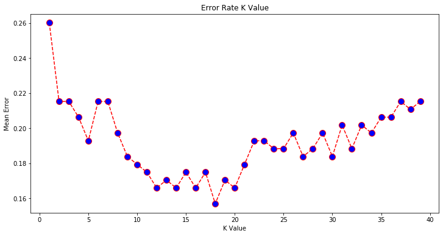

```python
plt.figure(figsize=(12, 6))
plt.plot(range(1,40), error, color='red', linestyle='dashed', marker='o',
         markerfacecolor='blue', markersize=10)
plt.title('Error Rate K Value')
plt.xlabel('K Value')
plt.ylabel('Mean Error')
plt.show()
```

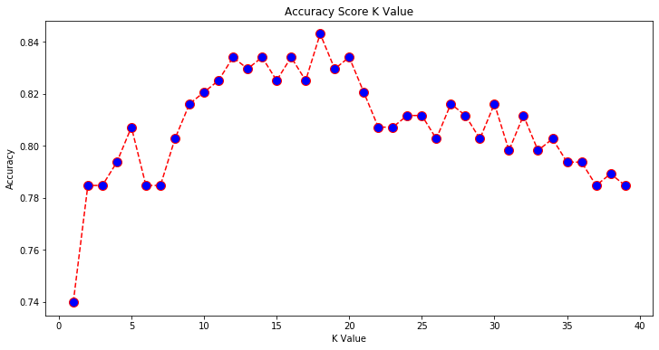

```python
plt.figure(figsize=(12, 6))
plt.plot(range(1,40), accuracy, color='red', linestyle='dashed', marker='o',
         markerfacecolor='blue', markersize=10)
plt.title('Accuracy Score K Value')
plt.xlabel('K Value')
plt.ylabel('Accuracy')
plt.show()
```

```python
from sklearn.neighbors import KNeighborsClassifier
knn = KNeighborsClassifier(n_neighbors=11)
knn.fit(x_train,y_train)
```

```
KNeighborsClassifier(algorithm='auto', leaf_size=30, metric='minkowski',
                     metric_params=None, n_jobs=None, n_neighbors=11, p=2,
                     weights='uniform')
```

```python
y_predict1 = knn.predict(x_test)
```

```python
confusion_matrix(y_test, y_predict1)
```

```
array([[125,  14],
       [ 25,  59]], dtype=int64)
```

```python
accuracy_score(y_test, y_predict1)
```

```
0.8251121076233184
```

```python
print("Accuracy(in %): ",round(metrics.accuracy_score(y_test,y_predict1)*100,2), "%")
```

```
Accuracy(in %):  82.51 %
```

**Therefore the accuracy obtained using KNN Classification Model is 82.51%.**

# 3) Decision Tree

**CREATING X AND Y**

```python
x=newship1.iloc[:,:-1].values
y=newship1.iloc[:,-1].values
```

```python
y.shape
```

```
(891,)
```

```python
x.shape
```

```
(891, 8)
```

**SPLITTING DATA INTO TRAIN AND TEST**

```python
from sklearn.model_selection import train_test_split
x_train,x_test,y_train,y_test=train_test_split(x,y,test_size=0.25,random_state=0)
```

```python
x_train.shape
```

```
(668, 8)
```

```python
x_test.shape
```

```
(223, 8)
```

```python
y_train.shape
```

```
(668,)
```

```python
y_test.shape
```

```
(223,)
```

**SCALING**

```python
from sklearn.preprocessing import StandardScaler
scaler=StandardScaler()
x_train=scaler.fit_transform(x_train)
x_test=scaler.transform(x_test)
```

**BUILDING THE MODEL**

```python
from sklearn.tree import DecisionTreeClassifier
```

```python
clf=DecisionTreeClassifier()
clf=clf.fit(x_train,y_train)

y_pred=clf.predict(x_test)
y_pred
```

```
array([0, 0, 0, 1, 1, 0, 1, 1, 1, 1, 0, 1, 0, 1, 1, 0, 0, 0, 0, 1, 0, 0,
       0, 0, 0, 1, 0, 1, 1, 0, 0, 1, 0, 1, 0, 0, 0, 1, 0, 0, 0, 1, 0, 0,
       1, 0, 0, 1, 0, 0, 0, 0, 1, 0, 0, 0, 0, 0, 0, 0, 0, 1, 1, 0, 1, 0,
       1, 0, 0, 1, 0, 1, 1, 0, 0, 1, 0, 0, 0, 1, 0, 1, 1, 0, 0, 1, 1, 0,
       1, 0, 0, 0, 1, 1, 0, 0, 1, 0, 0, 0, 0, 0, 0, 0, 0, 1, 1, 0, 0, 1,
       0, 1, 1, 0, 1, 1, 0, 1, 0, 1, 0, 0, 0, 0, 0, 0, 0, 0, 0, 0, 1, 0,
       0, 1, 0, 0, 0, 0, 0, 0, 1, 1, 0, 1, 1, 0, 0, 0, 1, 1, 0, 1, 1, 0,
       1, 1, 0, 0, 1, 1, 0, 0, 1, 0, 0, 0, 0, 1, 0, 0, 0, 1, 0, 0, 1, 0,
       1, 0, 0, 1, 1, 0, 0, 0, 0, 0, 1, 0, 0, 1, 0, 0, 1, 1, 0, 0, 0, 0,
       1, 0, 0, 0, 0, 0, 0, 0, 1, 1, 1, 0, 0, 0, 0, 1, 0, 0, 0, 1, 0, 1,
       0, 1, 0], dtype=int64)
```

```python
from sklearn import metrics
```

```python
print("Accuracy(in %): ",round(metrics.accuracy_score(y_test,y_pred)*100,2), "%")
```

```
Accuracy(in %):  79.82 %
```

```python
from sklearn.metrics import confusion_matrix
```

```python
cn = confusion_matrix(y_test,y_pred)
cn
```

```
array([[119,  20],
       [ 25,  59]], dtype=int64)
```

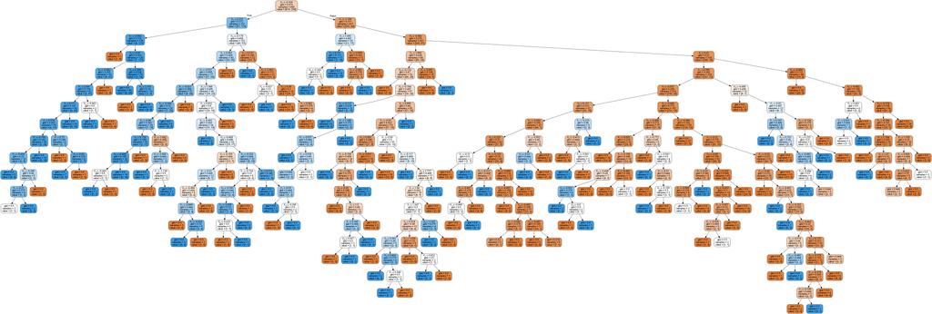

```python
#to display decision tree in graphical format
from sklearn.externals.six import StringIO
from IPython.display import Image
from sklearn.tree import export_graphviz
import pydotplus

dot_data=StringIO()
export_graphviz(clf,out_file=dot_data,filled=True,rounded=True,special_characters=True)
graph=pydotplus.graph_from_dot_data(dot_data.getvalue())
Image(graph.create_png(),width=12000,height=12000)
```

**Therefore the accuracy obtained using Decision Tree is 79.82%.**

# 4) Random Forest

**CREATING X AND Y**

```python
x=newship1.iloc[:,:-1].values
y=newship1.iloc[:,-1].values
```

```python
y.shape
```

```
(891,)
```

```python
x.shape
```

```
(891, 8)
```

**SPLITTING DATA INTO TRAIN AND TEST**

```python
from sklearn.model_selection import train_test_split
x_train,x_test,y_train,y_test=train_test_split(x,y,test_size=0.25,random_state=0)
```

```python
x_train.shape
```

```
(668, 8)
```

```python
x_test.shape
```

```
(223, 8)
```

```python
y_train.shape
```

```
(668,)
```

```python
y_test.shape
```

```
(223,)
```

**SCALING**

```python
from sklearn.preprocessing import StandardScaler
scaler=StandardScaler()
x_train=scaler.fit_transform(x_train)
x_test=scaler.transform(x_test)
```

**BUILDING THE MODEL**

```python
from sklearn.ensemble import RandomForestClassifier
```

```python
clf=RandomForestClassifier(n_estimators=10,n_jobs=2,random_state=0)
clf.fit(x_train,y_train)
```

```
RandomForestClassifier(bootstrap=True, class_weight=None, criterion='gini',
                       max_depth=None, max_features='auto', max_leaf_nodes=None,
                       min_impurity_decrease=0.0, min_impurity_split=None,
                       min_samples_leaf=1, min_samples_split=2,
                       min_weight_fraction_leaf=0.0, n_estimators=10, n_jobs=2,
                       oob_score=False, random_state=0, verbose=0,
                       warm_start=False)
```

```python
y_predict2=clf.predict(x_test)
y_predict2
```

```
array([0, 0, 0, 1, 1, 0, 1, 1, 1, 1, 0, 1, 0, 1, 1, 0, 0, 0, 0, 0, 0, 1,
       0, 0, 0, 1, 0, 1, 1, 0, 0, 1, 0, 1, 0, 0, 0, 0, 0, 0, 0, 0, 0, 0,
       1, 0, 0, 1, 0, 0, 0, 0, 1, 0, 0, 0, 0, 0, 0, 0, 1, 0, 1, 0, 1, 0,
       1, 0, 1, 1, 1, 0, 0, 0, 0, 1, 1, 0, 0, 0, 0, 0, 1, 0, 0, 1, 1, 1,
       1, 0, 0, 0, 1, 1, 0, 0, 1, 0, 0, 0, 0, 0, 0, 0, 0, 1, 1, 0, 0, 1,
       0, 1, 1, 0, 1, 1, 0, 1, 0, 1, 0, 0, 0, 0, 0, 0, 0, 0, 0, 0, 1, 0,
       0, 1, 0, 0, 0, 0, 0, 0, 1, 1, 0, 1, 1, 0, 0, 1, 1, 0, 0, 0, 1, 0,
       1, 0, 0, 0, 1, 1, 0, 0, 1, 0, 0, 0, 0, 0, 0, 0, 0, 1, 0, 0, 1, 0,
       1, 0, 0, 1, 0, 0, 0, 0, 0, 0, 1, 0, 0, 1, 0, 0, 1, 1, 0, 0, 0, 0,
       1, 0, 0, 0, 0, 1, 0, 0, 1, 1, 1, 0, 0, 0, 0, 1, 0, 0, 0, 0, 0, 1,
       0, 1, 1], dtype=int64)
```

```python
y_test
```

```
array([0, 0, 0, 1, 1, 1, 1, 1, 1, 1, 0, 1, 0, 1, 1, 0, 0, 0, 0, 1, 0, 1,
       0, 0, 0, 1, 0, 1, 1, 0, 0, 1, 0, 1, 0, 1, 0, 0, 0, 0, 1, 0, 0, 0,
       1, 0, 0, 1, 0, 0, 1, 1, 1, 0, 1, 0, 0, 0, 0, 1, 0, 0, 1, 0, 1, 0,
       1, 0, 1, 1, 1, 1, 0, 0, 0, 1, 0, 0, 0, 0, 0, 1, 0, 0, 0, 1, 1, 1,
       1, 0, 0, 0, 1, 1, 0, 0, 1, 0, 0, 1, 0, 0, 0, 0, 0, 1, 1, 0, 0, 1,
       0, 1, 1, 0, 1, 1, 1, 1, 0, 1, 1, 0, 0, 0, 0, 0, 0, 1, 0, 0, 0, 0,
       0, 0, 0, 0, 0, 0, 0, 0, 0, 1, 0, 0, 1, 0, 0, 1, 1, 0, 0, 1, 0, 0,
       1, 0, 0, 1, 0, 1, 0, 1, 1, 1, 0, 0, 0, 0, 0, 0, 0, 1, 0, 0, 1, 0,
       1, 0, 0, 0, 0, 0, 0, 0, 0, 0, 1, 0, 0, 1, 0, 0, 1, 1, 0, 0, 0, 1,
       1, 0, 1, 0, 0, 1, 1, 0, 0, 0, 1, 0, 0, 1, 0, 0, 0, 0, 0, 1, 0, 1,
       0, 1, 1], dtype=int64)
```

**ACCURACY METRICS**

```python
from sklearn import metrics
from sklearn.metrics import confusion_matrix
```

```python
cm=confusion_matrix(y_test,y_predict2)
cm
```

```
array([[126,  13],
       [ 23,  61]], dtype=int64)
```

```python
print("Accuracy(in %): ",round(metrics.accuracy_score(y_test,y_predict2)*100,2), "%")
```

```
Accuracy(in %):  83.86 %
```

```python
pd.crosstab(y_test,y_predict2,rownames=['Actual Status'],colnames=['Predicted Status'])
```

| Predicted Status Actual Status | 0 | 1 |
| --- | --- | --- |
| 0 | 126 | 13 |
| 1 | 23 | 61 |

**Therefore the accuracy obtained using Random Forest is 83.86%.**

# CONCLUSION:

Based on the Accuracy of the results, it can be thus concluded that for the given problem statement,

1) Accuracy obtained using Logistic Regression = 79%

2) Accuracy obtained using Decision Tree = 79.82%

3) Accuracy obtained using Random Forest = 83.86%

4) Accuracy obtained using KNN Classifier = 82.51%

- Therefore, **Random Forest Classification Model** gives the highest accuracy compared to Logistic Regression, KNN Classifier and Decision Tree with 83.86% accuracy and can be considered as the best model for this problem statement.